# Corona Virus and its' impact on crime in Chicago

The current corona-pandemic has had big impacts on societies all around the world. One of the places worst affected in the world is [United States of America](https://www.worldometers.info/coronavirus/country/us/) and therefore cities and companies have been shut down throughout the country and the americans are being forced to [stay at home](https://edition.cnn.com/2020/03/23/us/coronavirus-which-states-stay-at-home-order-trnd/index.html). This of course affects many things in the societies, one of which is crime rates.

As reported by [USAToday](https://eu.usatoday.com/story/news/investigations/2020/04/04/coronavirus-crime-rates-drop-and-domestic-violence-spikes/2939120001/) and [Forbes](https://www.forbes.com/sites/marleycoyne/2020/04/11/crime-rates-across-us-drop-amid-the-coronavirus-pandemic/#5e942087311e), crime rates throughout major cities of USA has dramatically dropped since the stay-at-home orders have been applied. In this study, we will visualize how crimes have decreased in the city of Chicago, Illinois and where the biggest impacts can be seen. A short outline of this web page is the following

- Analysis of the impact of Corona-virus in Illinois and more specifically Chicago and the Cook County. This included looking at the evolving pandemic in Illinois and how it affected movement of people.
- Crimes in the city of Chicago. Interactive plots to check the different types of crimes and how it currently has been compared to former years.
- An analysis of where crimes have occured in both 2019 and 2020 to get an overview of the locations of where the crimes have been comitted. This might show a different pattern, and show where people are obeying the stay-at-home orders in Chicago.
- Further analysis and predictions.

## Corona virus in Illinois, USA

As of 3th of May, 2020 a total of 1.2 million cases have been confirmed in the US. 62,000 of which are in the state of Illinois. The 7th worst county in the US is Cook County, which is the county containing most of Chicago. The current situation has a huge impace on the state of Illinois, and that is also why they chose from the 20th of March to close down the state, using the stay-at-home orders.

To get an overview of how the current situation is, we supply a map showing the situation in the different counties in Illinois. It is possible to use the mouse to hover over each county and get the general statistics of the situation in that specific county. Take a look at Cook County, where it can be seen, that the situation in Chicago is much worse than in the other counties. There are also a bit of peeks around the state. One can identify that the counties with the bigger cities are also the counties with the most cases and deaths due to the pandemic.

Make this Notebook Trusted to load map: File -> Trust Notebook

[interactive chart not shown]

As it can be seen, the situation in Illinois is dependent on where in the state one is. The more people, the more confirmed cases and deaths. Therefore, it seems quite relevant to focus on the Chicago area.

In order to see the details, you can hover over the different areas with your mouse.

Chicago is located in Cook County on the northeastern part of Illinois. Given that Chicago is the largest city in Illinois, it is also there most cases can be seen. This is visualized by the following plot, showing how the pandemic has evolved in the entire state of Illinois and how it compares to the evolving pandemic in Cook county.

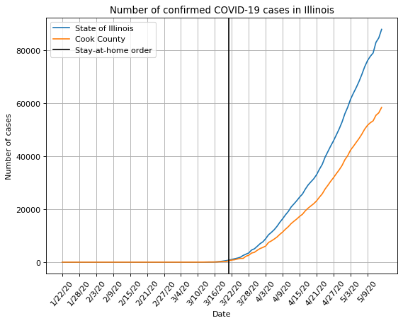

It is clear from the plot, that the most affected place in Illinois is around Chicago in Cook County, having by far the largest proportion of the total number of cases.

The effect on the daily life in Chicago is of course very high. Stay-at-home orders was issued in Illinois the [20th of March, 2020](https://www.chicago.gov/content/dam/city/depts/mayor/Press%20Room/Press%20Releases/2020/March/FAQsStayAtHomeOrder.pdf), and they have been extended through April. Since people are required to stay at home, huge effects can be seen. The time of the stay-at-home orders can be seen by the black line. It is quite clear that even though stay-at-home orders have veen applied, it was too late and the number of confirmed cases exploded. This might be due to people not following the orders or because people were already infected at that point.

### Movement of people in Cook County

To analyse whether or not people have been following the stay-at-home orders, it is very relevant to analyse how much movement of the people in Cook County has decreased after the orders were applied. To do so, a study performed by Descartes Labs can be used. The studies have measured the median of the longest movement a person has done in a day and the study can be found [here](https://www.descarteslabs.com/mobility/).

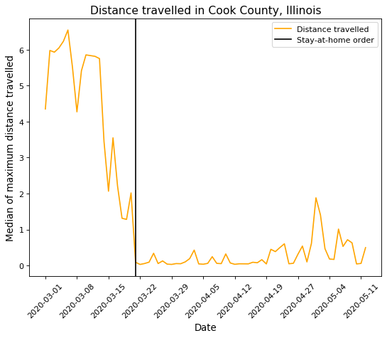

As it can be seen, already prior to the stay-at-home orders, movement of people in Cook County decreased rather rapidly. After the stay-at-home orders where introduced, one can see that the median of the maximum distance travelled is very low. This is therefore a strong indication that people are actually staying at home during the Corona pandemic.

Another important thing about distance travelled is how it affects the society in general in Cook County and in Chicago. Thereby we will now look at the crimes in Chicago, since media has reported it decreasing in major cities of USA, including Chicago.

## Crime in Chicago

Chicago has a [higher crime rate than average](https://en.wikipedia.org/wiki/Crime_in_Chicago) in the US. The city has a high rate of homicides and other violent crimes, and street gangs are evolving throughout the city. Chicago is regareded as the most gang-infected city in America, and thereby crimes of homicides, narcotica and burglary is not uncommon in the area.

However, crimes in Chicago has seen [a rapid decline](https://nypost.com/2020/04/11/crime-rates-drop-as-coronavirus-spreads/) over the course of the stay-at-home period. In this section, we will focus on how the crime have declined over the period. This includes the type of crimes which have seen a decline, where the crimes occur and why that might be.

The data is taken from the Chicago Police Department in the [Chicago City Portal](https://data.cityofchicago.org/Public-Safety/Crimes-2001-to-present/ijzp-q8t2).

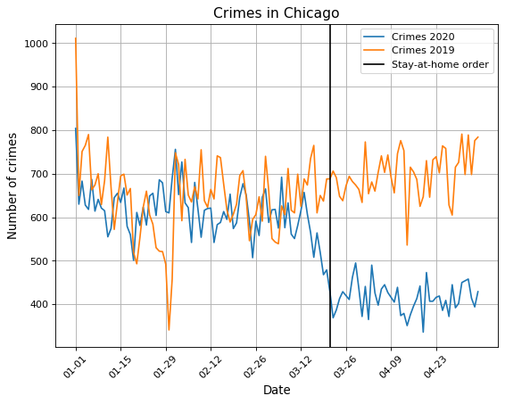

It should also be noted, that the big dip in the end of January is due to [near cold records](https://www.weather.gov/lot/RecordColdJan2019) in the nothern Illinois area. Therefore much less crime was reported, since a snowstorm had essentially frozen the city.

Now it is time to look at the different types of crimes.

### Type of Crime

Looking at the total number of crimes is not enough. It is by far more interesting to look at which types of crimes are more prone to changing due to the spreading of the virus. For simplicity, we will choose a subset of the types of crimes in Chicago. This is due to some of the crimes being very uncommon and thereby will not show any big differences, since the crimes do not occur every day.

The focus crimes focused on in this section are the following:

- Assault.
- Battery.
- Depective Practice.
- Motor Vehicle Theft.
- Narcotics
- Robbery
- Theft
- Criminal Damage

Other crimes in the data set includes gambling, arson, homicide and others. All can be seen in the previous link to the Chicago City Bank. Below is supplied a plot showing the amount of each crime happening in 2020 until the 18th of April, 2020. As it can be seen, the focus crimes chosen are the more common ones.

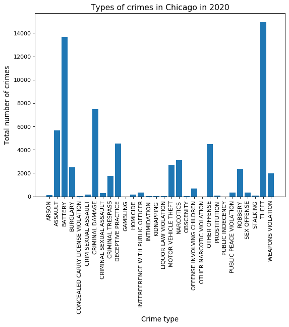

Of most interest is not how many crimes has happened in 2020, but rather comparing it to how it normally is. The easiest way to compare the crimes are by looking at how it was in 2019. Therefore, similar to the plot showing the total number of crimes, one can compare each specific type of crime to how it was last year.

In the following figure, it is possible to click the legend and select a specific crime. The number of crimes in 2020 and in 2019 will then show, so they are easy to compare.

Try to click on narcotics or theft. These are two types of crimes that have seen a rapid decrease in 2020 compared to 2019.

[interactive chart not shown]

When one dives into the plot, it is also clear that some types of crime does not see much of a change. Motor vehicle theft is an example. There can be several reasons for this, but given people are ordered to stay at home, it might be easier to steal cars. Robbery and burglary has not changed a lot either as opposed to theft. This seems reaonable, since a robbery happens when people are at home or at a store and burglary is breaking and entering. Theft on the other hand usually happens when people are not at home. Thereby, the theft numbers go down, since people are staying at home.

Just comparing the number of crimes to 2019 might be unprecise, and it would therefore be relevant to also look at other past years. This is to also argue that the decrease in number of crimes is not a common pattern, where it decreases every year. The following plot shows exactly that; the total number of crimes between 1st of March and 18th of April from year 2010 until year 2020. Again, one can choose the crime in the legend to be shown, and then see a comparisson between the years.

[interactive chart not shown]

A big difference can be seen, when selecting either theft or narcotics. This difference clearly shows that is is not a natural development of the number of crimes. Investigating these plots also shows how the total number of the focus crimes has decreased or increased throughout the years, which is also quite interesting.

Now we have looked at the amount of crimes of the specific focus crimes, and it is now very relevant to look at where these crimes have happened.

## Heat maps showing the crimes

This section is about heat maps. A heat map will show the distribution of the given data. Here, the heat maps will focus on crimes. The crimes in quesiton are the most affected by the Corona-virus, namely theft and narcotics. In these maps, it will be possible for the user to zoom in and out and check different places of Chicago.

### Theft

First focus is on theft. Theft is a recurring crime happening throughout all of the Chicago area. It is a very common crime, which will also be evident by the maps.

Check out the outskirts of the city. The main effect can be seen there. It is seemingly so, that the stay-at-home orders affects the outskirts of Chicago more than the downtown area. The left map shows the thefts in 2020 from 1st of March to 18th of April. The right map shows the thefts in 2019 in the same time period.

It is also quite interesting to see how the thefts are more dense in the 2019 map. This is also due to the rapid decrease in the number of thefts.

```
<folium.plugins.heat_map.HeatMap at 0x1ee771ca288>
```

[interactive chart not shown]

Feel free to zoom in and look at the specific places of where the crimes have happened.

### Narcotics

Narcotics is also a crime-type that has seen a rapid decrease. Similar to the maps above, the left map shows 2020 from the 1st of March to the 18th of April. The left map shows the crimes in 2019 in the same period. Similarly, one can zoom in and out and look at the different aspects of where the crimes have happened.

We encourage to look at the general distribution by zooming out. One can see that the area of where these crimes have happened have been shrinked in size quite a lot.

Further, take a look at the airports. Since airports have closed due to the Corona virus, the narcotic crimes are not happening there anymore. However, airports is normally a spot where there is quite a lot of narcotics.

[interactive chart not shown]

The general downtown area has also seen quite a decrease when comparing. This is also quite interesting.

## Prediction of the future

The focus until now has been to show the reader how the crimes in Chicago has developed as a result of the COVID-19 virus and the stay-at-home orders. We saw a rapid decrease. It was shown how specific types of crimes have developed and how they were different from previous years. Further, it was shown where the crimes have happened in both 2019 and 2020 to give the user an overview of the locations of the crimes.

Now we want to show how well one can predict crimes and corona data using machine learning. It should be noted, that machine learning only takes data into account. Therefore, these predictions might not be accurate due to outer forces working on the data. However, we will show in general that predictions can be used to somewhat accurately assess data.

The goal of this section is not to understand the underlying statistics, but rather getting the user to see how well machine learning can understand the data and predict the future.

### Prediction of corona cases

The first model we have developed is an univariate convolutional neural network. We are looking at the the confirmed COVID-19 cases, and the goal of the model is to make accurate one-step predictions. We are training the model on all data available except for the last 20 days.

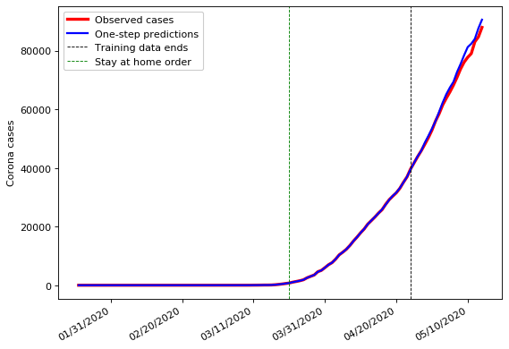

In the plot the blue line are representing the one-step predictions, the red line is representing the observed amount of corona cases, the green dashed line shows when the stay at home order is introduced, and the black dashed line shows when the training data set stops.

Convolutional neural networks have a stochastic behaviour, to deal with this we taken the mean of the one-step predictions for 100 models.

In the plot, we see that the prediction is pretty accurate for predicting tomorrow for the first 10 days after the training data ends. However, the prediction for the last week is in general higher than the observed number of corona cases. This could be due to the fact that the slope of the observed cases is lower for the 10th of May. This ilustrates quite well the drawback with the model developed. The model has not seen the slope decreasing before, and this makes it unable to predict what happens. However, if we disregard the predictions for the last week, the model performs quite good.

The example above is introduced as a proof of concept to see if convolutional neural networks can be used at all for prediction the total amount of corona cases. Now we will predict four time steps into the future.

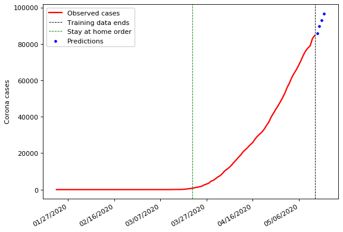

The mean of the predictions for 100 models for the next four days can be seen. However, please take the predictions with a grain of salt.

We can see that the prediction for tomorrow is quite low, and we would expect that the actual number of cases is higher tomorrow, but only time will tell.

### Prediction of crime and corona cases

Now we will use the crime date to develop a better model for one step predictions. When the amount of corona cases is increasing, the amount of crime is decreasing. It can be argumented that the relationship is not multivariate, but the decreasing crime rate is merely a consequence. However, we will use this relationship for our next model: a convolutional neural network for predicting one-step predictions a multivariate time series.

[interactive chart not shown]

The lines are representing the number of crimes. The dark lines are predictions and lighter lines are observation. The green dashed line shows when the stay at home order is introduced, and the black dashed line shows when the training data set stops.

It is seen that the one step prediction become inaccurate after the stay at home order is introduced. However, the inaccuracy becomes larger as the amount of crime is slowly rising again. Furthermore, it is seen that the amount of crime before the stay at home order follow stationary processess, this stops just days before the stay at home order.

You are encourage to click on the differnt types of crime to see how the predictions compare to the observed amount of corona cases.

Overall, it is seen that the predictions for the different types of crimes are okay. However, it is interesting to see if the COVID-19 one step predictions are improved by using the information from the crime data set.

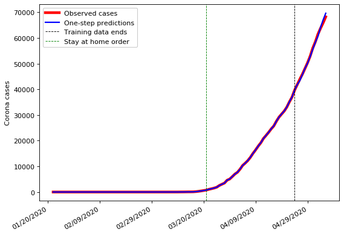

In the plot, it is hard to distinguish the predicted and observed values. Actually, the lines a plotted almost perfectly on top of each other. This means that even though the predictions of the different types of crimes was mediocre, the predictions for COVID-19 are good. Furthermore, the one-step predictions have improved when we compare to the predictions for the univariate model. It has improved the model to include the crime data.

However, before we get to excited, we should again note the limitations of the model - it can only predict what it has seen before.

Further work could be to develop a model that predicts several time steps into the future using the crime data.

## Interested in more?

The we got just the link for you! [Here](https://neeljansen.github.io/SocialDataAnalysisFinalProject/ExamProjectExplainer.html?fbclid=IwAR3wJCae5Ceo7s30cCLCiLlSG-AvaAHpwTDXphUB2AF3MS5PViMn2DDZyxQ) you will find a our full analysis, code and description of how we chose to visualize our findings. It is the "explainer" for this webpage.